# Peter_Ye_NLP_Assignment_2

### Assignment 2

### Peter Ye

**Note:** your records counts will be different, depending on when you query the API

```python
import pandas as pd
import requests
import re
import nltk.corpus
from nltk.text import Text
import matplotlib.pyplot as plt
import string
from collections import Counter
from nltk.tokenize import word_tokenize
from nltk.corpus import stopwords
from nltk import FreqDist
from nltk.stem import PorterStemmer
from nltk.stem import LancasterStemmer
pd.options.mode.chained_assignment = None  # default='warn'
pd.set_option('max_colwidth',None)
```

## Fetch the data

```python
%%time

# Define the API endpoint and parameters
url = "https://data.cityofchicago.org/resource/cwig-ma7x.json"

# Fetch the total count of records
def get_total_count(url):
    params = {
        "$select": "count(*)"
    }
    response = requests.get(url, params=params)
    data = response.json()
    return int(data[0]['count'])

total_count = get_total_count(url)
print(f"Total number of records available: {total_count:,.0f}")
```

```
Total number of records available: 266,257
CPU times: user 25.7 ms, sys: 6.35 ms, total: 32.1 ms
Wall time: 398 ms
```

```python
%%time

# Fetch data and load it into a pandas DataFrame
def fetch_data(url, params):
    response = requests.get(url, params=params)
    data = response.json()
    return pd.DataFrame(data)

# Set the limit parameter equal to the number of available records
params = {
    "$limit": total_count
}

# Fetch the data and load it into a DataFrame
df = fetch_data(url, params)

print(f'Number of records retrieved: {df.shape[0]:,.0f}')
```

```
Number of records retrieved: 266,257
CPU times: user 10.9 s, sys: 2.47 s, total: 13.4 s
Wall time: 33.3 s
```

## Check the data

```python
# Check the data
df.head(10)
```

|  | inspection_id | dba_name | aka_name | license_ | facility_type | risk | address | city | state | zip | ... | results | violations | latitude | longitude | location | :@computed_region_awaf_s7ux | :@computed_region_6mkv_f3dw | :@computed_region_vrxf_vc4k | :@computed_region_bdys_3d7i | :@computed_region_43wa_7qmu |
| --- | --- | --- | --- | --- | --- | --- | --- | --- | --- | --- | --- | --- | --- | --- | --- | --- | --- | --- | --- | --- | --- |
| 0 | 2588033 | MR. TACO MEX, INC. | MR. TACO MEX, INC. | 2813393 | Restaurant | Risk 1 (High) | 10656 S TORRENCE AVE | CHICAGO | IL | 60617 | ... | Pass w/ Conditions | 10. ADEQUATE HANDWASHING SINKS PROPERLY SUPPLIED AND ACCESSIBLE - Comments: OBSERVED NO HAND WASHING SIGN AT REAR HAND WASHING SINK. INSTRUCTED MANAGER TO PROVIDE HAND WASHING SIGNS AT ALL HAND WASHIN… | 41.70112036721256 | -87.55972431384708 | {'type': 'Point', 'coordinates': [-87.55972431384708, 41.70112036721256]} | 47 | 21202 | 48 | 174 | 47 |
| 1 | 2588029 | SHAN GROCERY | SHAN GROCERY | 2948565 | Grocery Store | Risk 2 (Medium) | 5060 N SHERIDAN RD | CHICAGO | IL | 60640 | ... | Pass | 49. NON-FOOD/FOOD CONTACT SURFACES CLEAN - Comments: INSTRUCTED TO CLEAN AND MAINTAIN CONDENSER FAN COVER WITH DUST ACCUMULATION INSIDE REAR WALK-IN COOLER. \| 55. PHYSICAL FACILITIES INSTALLED, MAINT… | 41.975119077312534 | -87.65512202484139 | {'type': 'Point', 'coordinates': [-87.65512202484139, 41.975119077312534]} | 37 | 22616 | 31 | 634 | 16 |
| 2 | 2588048 | HIENIE'S | HIENIE'S | 2578472 | Restaurant | Risk 1 (High) | 10359 S TORRENCE AVE | CHICAGO | IL | 60617 | ... | Pass | 49. NON-FOOD/FOOD CONTACT SURFACES CLEAN - Comments: OBSERVED GREASE BUILDUP, FOOD DEBRIS AND SPILLS ON INTERIOR AND EXTERIOR SURFACES OF FRYERS, PREP TABLES, HOLDING UNITS, SHELVING UNITS, COOKING EQ… | 41.70648742697794 | -87.55949850858342 | {'type': 'Point', 'coordinates': [-87.55949850858342, 41.70648742697794]} | 47 | 21202 | 48 | 527 | 47 |
| 3 | 2588031 | SHAN FOOD | SHAN FOOD | 2523608 | Restaurant | Risk 1 (High) | 5060 N SHERIDAN RD | CHICAGO | IL | 60640 | ... | Out of Business | NaN | 41.975119077312534 | -87.65512202484139 | {'type': 'Point', 'coordinates': [-87.65512202484139, 41.975119077312534]} | 37 | 22616 | 31 | 634 | 16 |
| 4 | 2588059 | BRIGHT SCHOLARS ACADEMY, LLC | BRIGHT SCHOLARS ACADEMY | 2506770 | Children's Services Facility | Risk 1 (High) | 8501-8503 S ASHLAND AVE | CHICAGO | IL | 60620 | ... | Fail | 10. ADEQUATE HANDWASHING SINKS PROPERLY SUPPLIED AND ACCESSIBLE - Comments: OBSERVED HOT RUNNING WATER TEMPERATURE AT HAND SINKS IN KITCHEN - 87.8F.GIRL'S TOILET ROOM - 87.1F-87.4F.BOY'S TOILET ROOM-8… | 41.739343208088016 | -87.66300791918849 | {'type': 'Point', 'coordinates': [-87.66300791918849, 41.739343208088016]} | 18 | 21554 | 70 | 531 | 13 |
| 5 | 2588041 | CERES FOOD GROUP,INC. | (SCHOOL) PERSPECTIVES IIT MATH & SCIENCE | 3709480 | School | Risk 1 (High) | 3663 S WABASH AVE | CHICAGO | IL | 60653 | ... | No Entry | NaN | 41.82779592823685 | -87.62475128513913 | {'type': 'Point', 'coordinates': [-87.62475128513913, 41.82779592823685]} | 12 | 4301 | 1 | 446 | 9 |
| 6 | 2588065 | TEMPORIS | TEMPORIS | 2446729 | Restaurant | Risk 1 (High) | 933 N ASHLAND AVE | CHICAGO | IL | 60622 | ... | No Entry | NaN | 41.89890432084078 | -87.66722318342336 | {'type': 'Point', 'coordinates': [-87.66722318342336, 41.89890432084078]} | 41 | 21560 | 25 | 484 | 41 |
| 7 | 2588024 | U OF C (CS) DONOGHUE | UNIVERSITY OF CHICAGO CHARTER SCHOOL DONOGHUE | 66321 | School | Risk 1 (High) | 707 E 37TH ST | CHICAGO | IL | 60653 | ... | Pass | 10. ADEQUATE HANDWASHING SINKS PROPERLY SUPPLIED AND ACCESSIBLE - Comments: OBSERVED ONE THE HAND SINK IN THE GIRLS 1st FLOOR WASHROOM NEAR THE KITCHEN WITH LOW PRESSURE AND THE TIMER ON SINK MUST STA… | 41.8277051679405 | -87.60847172435795 | {'type': 'Point', 'coordinates': [-87.60847172435795, 41.8277051679405]} | 1 | 4301 | 2 | 221 | 10 |
| 8 | 2588013 | SOLOWAY COFFEE | SOLOWAY COFFEE | 2938639 | Restaurant | Risk 1 (High) | 2275 N LINCOLN AVE | CHICAGO | IL | 60614 | ... | Pass w/ Conditions | 3. MANAGEMENT, FOOD EMPLOYEE AND CONDITIONAL EMPLOYEE; KNOWLEDGE, RESPONSIBILITIES AND REPORTING - Comments: OBSERVED NO EMPLOYEE HEALTH POLICY ON SITE. INSTRUCTED TO PROVIDE AN EMPLOYEE HEALTH POLICY… | 41.92361620972698 | -87.64599112233753 | {'type': 'Point', 'coordinates': [-87.64599112233753, 41.92361620972698]} | 51 | 21190 | 68 | 798 | 34 |
| 9 | 2588023 | BARTON ELEMENTARY SCHOOL | BARTON ELEMENTARY SCHOOL | 22151 | School | Risk 1 (High) | 7650 S Wolcott (1900W) | CHICAGO | IL | 60620 | ... | Fail | 3. MANAGEMENT, FOOD EMPLOYEE AND CONDITIONAL EMPLOYEE; KNOWLEDGE, RESPONSIBILITIES AND REPORTING - Comments: OBSERVED NO SIGNED EMPLOYEES HEALTH POLICIES MUST PROVIDE AND MAINTAIN.(PRIORITY FOUNDATION… | 41.75421962168018 | -87.67096452829065 | {'type': 'Point', 'coordinates': [-87.67096452829065, 41.75421962168018]} | 6 | 21554 | 70 | 573 | 31 |

10 rows × 22 columns

## Clean the data

```python
# Select only the records corresponding to failed inspection (see "results" column)
failed_records = df[df['results'] == 'Fail']

# Clean the data, making sure that there are no NaNs in "violations" column
df_cleaned = failed_records.dropna(subset=['violations'])
```

```python
# Regular expression to match the description and optionally comments
pattern = r'\d+\.\s(.*?)(?:\s+-\sComments:\s([^|]*)|(?=\s*\||$))'

# Function to extract descriptions and optionally comments
def extract_descriptions_comments(violation_text):
    # Split the text by "|" and then apply the regex to each part
    parts = violation_text.split('|')
    descriptions = []
    comments = []

    for part in parts:
        match = re.search(pattern, part)
        if match:
            # Append description
            descriptions.append(match.group(1).strip())
            # Append comment if available, else an empty string
            comments.append(match.group(2).strip() if match.group(2) else '')
        else:
            # Append empty strings if no match is found
            descriptions.append('')
            comments.append('')

    return descriptions, comments

# Apply the function to the 'violations' column
df_cleaned['description_only'], df_cleaned['comment_only'] = zip(*df_cleaned['violations'].apply(extract_descriptions_comments))
```

## Tokenize

```python
# Function to tokenize and clean text
def tokenize(text):
    # Tokenize
    tokens = word_tokenize(str(text))
    return tokens

# Tokenize the text in each column
df_cleaned['description_tokens'] = df_cleaned['description_only'].apply(tokenize)
df_cleaned['comment_tokens'] = df_cleaned['comment_only'].apply(tokenize)

# Use FreqDist to count the frequencies of tokens in each column
description_freqdist = FreqDist(token for sublist in df_cleaned['description_tokens'] for token in sublist)
comment_freqdist = FreqDist(token for sublist in df_cleaned['comment_tokens'] for token in sublist)

# Get the top-10 tokens for each column
top_10_description_tokens = description_freqdist.most_common(10)
top_10_comment_tokens = comment_freqdist.most_common(10)
```

```python
print("Top 10 Description Tokens without Cleaned:")
print(top_10_description_tokens)
print("Top 10 Comment Tokens without Cleaned:")
print(top_10_comment_tokens)
```

```
Top 10 Description Tokens without Cleaned:
[(',', 645379), ("'", 325939), ('AND', 172958), (':', 128991), ('MAINTAINED', 89337), ('&', 80654), ('PROPERLY', 74635), ('INSTALLED', 69338), ('CLEAN', 68773), ('CONSTRUCTED', 68327)]
Top 10 Comment Tokens without Cleaned:
[('.', 739319), (',', 629361), ('AND', 376141), ("'", 331200), ('THE', 275244), ('IN', 251371), ('TO', 240637), ('OF', 162783), ('ON', 143698), ('AT', 131119)]
```

```python
# Function to tokenize and clean text
def tokenize_and_clean(text):
    # Convert to lowercase
    text = str(text).lower()
    # Tokenize
    tokens = word_tokenize(text)
    # Remove punctuation and stopwords
    stop_words = set(stopwords.words('english'))
    tokens = [token for token in tokens if token.isalpha() and token not in stop_words]
    return tokens

# Tokenize the text in each column
df_cleaned['description_tokens'] = df_cleaned['description_only'].apply(tokenize_and_clean)
df_cleaned['comment_tokens'] = df_cleaned['comment_only'].apply(tokenize_and_clean)

# Use FreqDist to count the frequencies of tokens in each column
description_freqdist = FreqDist(token for sublist in df_cleaned['description_tokens'] for token in sublist)
comment_freqdist = FreqDist(token for sublist in df_cleaned['comment_tokens'] for token in sublist)

# Get the top-10 tokens for each column
top_10_description_tokens_cleaned = description_freqdist.most_common(10)
top_10_comment_tokens_cleaned = comment_freqdist.most_common(10)
```

```python
print("Top 10 Description Cleaned Tokens:")
print(top_10_description_tokens_cleaned)
print("Top 10 Comment Cleaned Tokens:")
print(top_10_comment_tokens_cleaned)
```

```
Top 10 Description Cleaned Tokens:
[('maintained', 89337), ('properly', 74635), ('installed', 69338), ('clean', 68773), ('constructed', 68327), ('equipment', 64932), ('surfaces', 51531), ('cleaning', 48295), ('contact', 47996), ('used', 42744)]
Top 10 Comment Cleaned Tokens:
[('food', 134449), ('instructed', 129593), ('must', 127309), ('clean', 108960), ('area', 106147), ('maintain', 90528), ('prep', 85377), ('sink', 85083), ('provide', 74724), ('violation', 70062)]
```

## Porter Stemmer

```python
# Initialize the Porter stemmer
stemmer = PorterStemmer()

# Function to tokenize, clean, and stem text
def tokenize_clean_stem(text):
    # Convert to lowercase
    text = str(text).lower()
    # Tokenize
    tokens = word_tokenize(text)
    # Remove punctuation, stopwords, and non-alphabetic tokens, then apply stemming
    stop_words = set(stopwords.words('english'))
    stemmed_tokens = [stemmer.stem(token) for token in tokens if token.isalpha() and token not in stop_words]
    return stemmed_tokens

# Tokenize, clean, and stem the text in each column
df_cleaned['description_tokens_stemmed'] = df_cleaned['description_only'].apply(tokenize_clean_stem)
df_cleaned['comment_tokens_stemmed'] = df_cleaned['comment_only'].apply(tokenize_clean_stem)

# Use FreqDist to count the frequencies of stemmed tokens in each column
description_freqdist = FreqDist(token for sublist in df_cleaned['description_tokens_stemmed'] for token in sublist)
comment_freqdist = FreqDist(token for sublist in df_cleaned['comment_tokens_stemmed'] for token in sublist)

# Get the top-10 tokens for each stemmed column
top_10_description_tokens_porter = description_freqdist.most_common(10)
top_10_comment_tokens_porter = comment_freqdist.most_common(10)
```

```python
print("Top 10 Description Tokens with Porter Stemmer:")
print(top_10_description_tokens_porter)
print("Top 10 Comment Tokens with Porter Stemmer:")
print(top_10_comment_tokens_porter)
```

```
Top 10 Description Tokens with Porter Stemmer:
[('clean', 144332), ('maintain', 92886), ('properli', 74635), ('instal', 69338), ('construct', 68327), ('equip', 64932), ('surfac', 51531), ('contact', 47996), ('use', 42870), ('method', 41369)]
Top 10 Comment Tokens with Porter Stemmer:
[('food', 160180), ('area', 145349), ('clean', 135984), ('instruct', 129789), ('must', 127314), ('sink', 101887), ('maintain', 101456), ('floor', 90488), ('provid', 87198), ('prep', 85980)]
```

## Lancaster Stemmer

```python
# Create an instance of the LancasterStemmer
lancaster = LancasterStemmer()

# Function to tokenize, clean, and stem text
def tokenize_clean_stem(text):
    # Convert to lowercase
    text = str(text).lower()
    # Tokenize
    tokens = word_tokenize(text)
    # Remove punctuation, stopwords, and non-alphabetic tokens, then apply stemming
    stop_words = set(stopwords.words('english'))
    stemmed_tokens = [lancaster.stem(token) for token in tokens if token.isalpha() and token not in stop_words]
    return stemmed_tokens

# Tokenize, clean, and stem the text in each column
df_cleaned['description_tokens_stemmed'] = df_cleaned['description_only'].apply(tokenize_clean_stem)
df_cleaned['comment_tokens_stemmed'] = df_cleaned['comment_only'].apply(tokenize_clean_stem)

# Use FreqDist to count the frequencies of stemmed tokens in each column
description_stem_freqdist = FreqDist(token for sublist in df_cleaned['description_tokens_stemmed'] for token in sublist)
comment_stem_freqdist = FreqDist(token for sublist in df_cleaned['comment_tokens_stemmed'] for token in sublist)

# Get the top-10 tokens for each stemmed column
top_10_description_tokens_lancaster = description_stem_freqdist.most_common(10)
top_10_comment_tokens_lancaster = comment_stem_freqdist.most_common(10)
```

```python
print("Top 10 Description Tokens with Lancaster Stemmer:")
print(top_10_description_tokens_lancaster)
print("Top 10 Comment Tokens with Lancaster Stemmer:")
print(top_10_comment_tokens_lancaster)
```

```
Top 10 Description Tokens with Lancaster Stemmer:
[('cle', 153847), ('maintain', 92886), ('prop', 86631), ('instal', 69338), ('construct', 68327), ('equip', 64932), ('surfac', 51531), ('contact', 47996), ('us', 42870), ('method', 41369)]
Top 10 Comment Tokens with Lancaster Stemmer:
[('food', 160181), ('cle', 148703), ('instruct', 129823), ('must', 127315), ('are', 106147), ('prep', 103772), ('sink', 101889), ('maintain', 101470), ('stor', 99479), ('flo', 91607)]
```

## lemmatization

```python
# Create an instance of the lemmatization
wnl = nltk.WordNetLemmatizer()

# Function to tokenize, clean, and lemma text
def tokenize_clean_stem(text):
    # Convert to lowercase
    text = str(text).lower()
    # Tokenize
    tokens = word_tokenize(text)
    # Remove punctuation, stopwords, and non-alphabetic tokens, then apply stemming
    stop_words = set(stopwords.words('english'))
    stemmed_tokens = [wnl.lemmatize(token) for token in tokens if token.isalpha() and token not in stop_words]
    return stemmed_tokens

# Tokenize, clean, and stem the text in each column
df_cleaned['description_tokens_lem'] = df_cleaned['description_only'].apply(tokenize_clean_stem)
df_cleaned['comment_tokens_lem'] = df_cleaned['comment_only'].apply(tokenize_clean_stem)

# Use FreqDist to count the frequencies of stemmed tokens in each column
description_lem_freqdist = FreqDist(token for sublist in df_cleaned['description_tokens_lem'] for token in sublist)
comment_lem_freqdist = FreqDist(token for sublist in df_cleaned['comment_tokens_lem'] for token in sublist)

# Get the top-10 tokens for each lemmed column
top_10_description_tokens_lemma = description_lem_freqdist.most_common(10)
top_10_comment_stemmed_lemma = comment_lem_freqdist.most_common(10)
```

```python
print("Top 10 Description Tokens with lemmatization:")
print(top_10_description_tokens_lemma)
print("Top 10 Comment Tokens with lemmatization:")
print(top_10_comment_stemmed_lemma)
```

```
Top 10 Description Tokens with lemmatization:
[('maintained', 89337), ('properly', 74635), ('installed', 69338), ('clean', 68773), ('constructed', 68327), ('equipment', 64932), ('surface', 51531), ('cleaning', 48295), ('contact', 47996), ('used', 42744)]
Top 10 Comment Tokens with lemmatization:
[('food', 160179), ('area', 145350), ('instructed', 129593), ('must', 127313), ('clean', 108967), ('sink', 101886), ('maintain', 90528), ('floor', 90116), ('prep', 85390), ('violation', 78397)]
```

## Compare top-10 tokens & Describe the Mmost comprehensive view of violations / comments and why

### Top 10 Description Tokens without Cleaned:

- Contains common English words and punctuation marks.
- Words like 'MAINTAINED', 'PROPERLY', 'INSTALLED', 'CLEAN', and 'CONSTRUCTED' indicate a focus on maintenance, proper installation, cleanliness, and construction of facilities or equipment.

### Top 10 Comment Tokens without Cleaned:

- Similar to descriptions, but with more focus on actions and locations, as indicated by words like 'THE', 'IN', 'TO', 'OF', 'ON', 'AT'.
- These tokens suggest comments are more detailed about specific actions or locations related to the violations.

### Top 10 Description Cleaned Tokens:

- More meaningful as stopwords and punctuation are removed.
- 'maintained', 'properly', 'installed', 'clean', 'constructed', 'equipment', 'surfaces' suggest a strong emphasis on the physical state and maintenance of equipment and facilities.

### Top 10 Comment Cleaned Tokens:

- Tokens like 'food', 'instructed', 'must', 'clean', 'area', 'maintain', 'prep', 'sink', 'provide' suggest comments are often directives or observations related to food handling, cleanliness, and equipment maintenance.

### Top 10 Tokens with Porter Stemming:

- Stemming reduces words to their base forms, like 'properli' for 'properly', 'instal' for 'install'.
- Focus remains similar to the cleaned tokens but provides a condensed version of words. For example, 'clean', 'maintain' are common in both descriptions and comments, emphasizing maintenance and cleanliness.

### Top 10 Tokens with Lancaster Stemming:

- More aggressive stemming than Porter, resulting in even more condensed forms like 'cle' for 'clean', 'prop' for 'properly'.
- Despite the aggressive stemming, the focus on maintenance and cleanliness remains evident.

### Top 10 Tokens with Lemmatization:

- Lemmatization provides a more readable form than stemming, showing 'maintained', 'properly', 'installed', 'clean', 'constructed'.
- Indicates a focus similar to the cleaned tokens, emphasizing the proper maintenance and condition of facilities and equipment.

### Comprehensive View:

- The top tokens across different methods consistently highlight themes of maintenance, cleanliness, and proper installation or construction, both in descriptions and comments. However, the cleaned and lemmatized tokens provide a more precise and readable insight. The cleaned tokens remove unnecessary elements (like punctuation and stopwords), and the lemmatized tokens preserve the original form of words, which makes them more interpretable.
- The comments, specifically in the cleaned and lemmatized tokens, suggest a focus on directives and observations related to food handling, cleanliness, and the condition of equipment and facilities. This indicates that comments often include specific instructions or details about the nature of the violation, emphasizing corrective actions or areas of concern.
- In conclusion, the most comprehensive view is provided by the cleaned and lemmatized tokens, as they maintain the balance between readability and meaningful representation of the data, highlighting the central themes of maintenance, cleanliness, and proper handling in the context of the violations and comments.

## Lemmatization Tokens over Time

```python
# Extract Year from 'inspection_time'
df_cleaned['Year'] = pd.to_datetime(df_cleaned['inspection_date']).dt.year

# top_10_tokens contains the top 10 tokens as a list of strings
top_10_tokens = [token[0] for token in top_10_description_tokens_lemma]

# Function to filter top 10 tokens
def filter_top_10_tokens(tokens):
    return [token for token in tokens if token in top_10_tokens]

# Apply the filter function
df_cleaned['filtered_description_tokens'] = df_cleaned['description_tokens_lem'].apply(filter_top_10_tokens)

# Initialize a dictionary to store token frequencies by year
token_freq_by_year = {token: [] for token in top_10_tokens}
years = sorted(df_cleaned['Year'].unique())

# Count occurrences of each token per year
for year in years:
    year_data = df_cleaned[df_cleaned['Year'] == year]
    all_tokens = [token for sublist in year_data['filtered_description_tokens'] for token in sublist]
    year_freq_dist = FreqDist(all_tokens)

    for token in top_10_tokens:
        token_freq_by_year[token].append(year_freq_dist[token])

# Convert the dictionary to a DataFrame
top_tokens_over_time_df = pd.DataFrame(token_freq_by_year, index=years)

top_tokens_over_time_df
```

|  | maintained | properly | installed | clean | constructed | equipment | surface | cleaning | contact | used |
| --- | --- | --- | --- | --- | --- | --- | --- | --- | --- | --- |
| 2010 | 7510 | 4597 | 4791 | 5068 | 6776 | 7727 | 4109 | 6016 | 3781 | 2364 |
| 2011 | 8316 | 5154 | 5335 | 5304 | 7333 | 8228 | 4378 | 6387 | 4135 | 2555 |
| 2012 | 7199 | 4525 | 4511 | 4656 | 6206 | 6967 | 3588 | 5493 | 3472 | 2211 |
| 2013 | 6575 | 4087 | 4142 | 4107 | 5550 | 6163 | 3152 | 4805 | 3149 | 2020 |
| 2014 | 7245 | 4614 | 4417 | 4726 | 6186 | 7029 | 3647 | 5404 | 3607 | 2207 |
| 2015 | 7182 | 4503 | 4297 | 4887 | 6270 | 6982 | 3831 | 5313 | 3754 | 2139 |
| 2016 | 7970 | 5056 | 4841 | 5726 | 7178 | 7991 | 4390 | 6160 | 4389 | 2494 |
| 2017 | 7736 | 4943 | 4614 | 5183 | 6846 | 7453 | 4145 | 5863 | 4105 | 2408 |
| 2018 | 5884 | 4974 | 4775 | 4724 | 4058 | 3960 | 3436 | 2854 | 3109 | 2950 |
| 2019 | 5562 | 7026 | 6601 | 5551 | 2490 | 556 | 3636 | 0 | 3105 | 4818 |
| 2020 | 4313 | 5668 | 5079 | 4241 | 2252 | 331 | 2740 | 0 | 2395 | 3677 |
| 2021 | 4033 | 5716 | 4818 | 4244 | 2225 | 446 | 2958 | 0 | 2622 | 3864 |
| 2022 | 4420 | 6250 | 5068 | 4751 | 2357 | 492 | 3478 | 0 | 2994 | 4144 |
| 2023 | 5288 | 7373 | 5930 | 5500 | 2543 | 599 | 3965 | 0 | 3315 | 4802 |
| 2024 | 104 | 149 | 119 | 105 | 57 | 8 | 78 | 0 | 64 | 91 |

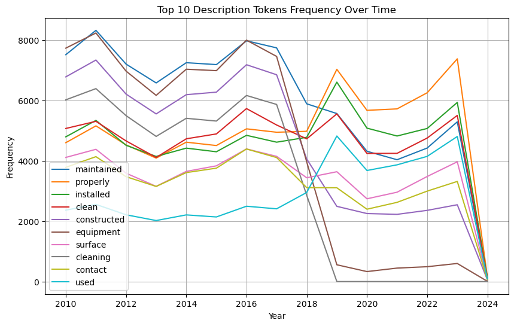

```python
# Plotting
plt.figure(figsize=(10, 6))
for column in top_tokens_over_time_df.columns:
    plt.plot(top_tokens_over_time_df.index, top_tokens_over_time_df[column], label=column)

plt.title('Top 10 Description Tokens Frequency Over Time')
plt.xlabel('Year')
plt.ylabel('Frequency')
plt.legend()
plt.grid(True)
plt.show()
```